# Pronóstico de Ventas - Apple

Hugo César Octavio del Sueldo

11/15/2020

## Introducción

El objetivo es predecir las ventas de **Apple**. Para ello, hemos acudido a *Bloomberg* y hemos obtenido los datos trimestrales desde el 2T de 2008 hasta el 3T del 2017. (IngresosApple.csv).

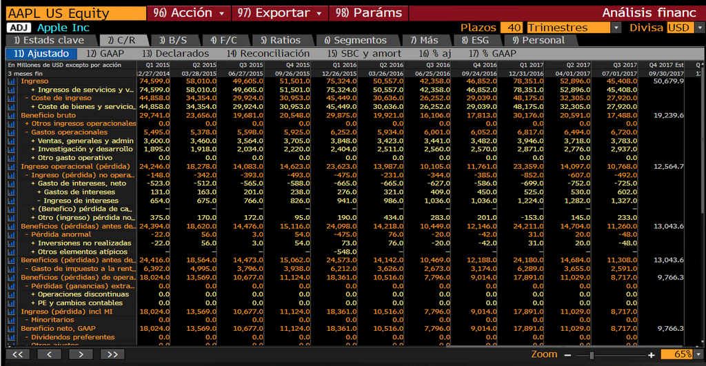

En el gráfico adjunto se representan los ingresos desde el 1º trimestre del 2005 hasta el 3º del 2017.

[figure not shown]

Se debe elegir el modelo ETS y el modelo ARIMA que mejor predice las ventas, habiendo dejado fuera de la estimación los trimestres del 2017.

Para comprender mejor lo que esta ocurriendo con las ventas de Apple, el siguiente articulo apareció en el “Wall Street Journal” en el fin de semana del 23/24 de Septiembre de 2017 y los ingresos por segmentos.

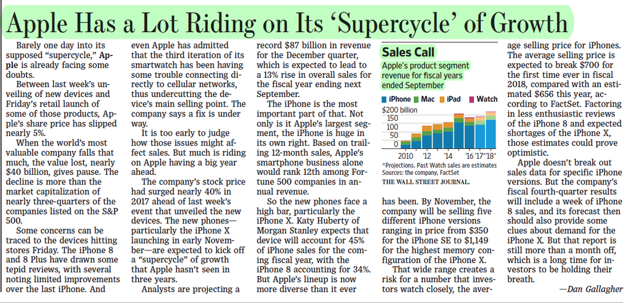

[figure not shown]

[figure not shown]

```r
require(forecast)
require(xts)
```

```r
require(ggplot2)
# read data from CSV file
rawData <- read.csv("IngresosApple.csv", sep=";", dec=",")

#observamos los tipos de objetos dentro del fichero
str(rawData)
```

```
## 'data.frame':    38 obs. of  2 variables:
##  $ Trimestre: chr  "Q2 2008" "Q3 2008" "Q4 2008" "Q1 2009" ...
##  $ Ingresos : int  7980 7561 11520 11880 9084 9734 12207 15683 13499 15700 ...
```

```r
#cambiamos las fechas por fechas
rawDate <- seq(as.Date("2008-04-01"), as.Date("2017-09-30"), by = "quarter")
rawDate
```

```
##  [1] "2008-04-01" "2008-07-01" "2008-10-01" "2009-01-01" "2009-04-01"
##  [6] "2009-07-01" "2009-10-01" "2010-01-01" "2010-04-01" "2010-07-01"
## [11] "2010-10-01" "2011-01-01" "2011-04-01" "2011-07-01" "2011-10-01"
## [16] "2012-01-01" "2012-04-01" "2012-07-01" "2012-10-01" "2013-01-01"
## [21] "2013-04-01" "2013-07-01" "2013-10-01" "2014-01-01" "2014-04-01"
## [26] "2014-07-01" "2014-10-01" "2015-01-01" "2015-04-01" "2015-07-01"
## [31] "2015-10-01" "2016-01-01" "2016-04-01" "2016-07-01" "2016-10-01"
## [36] "2017-01-01" "2017-04-01" "2017-07-01"
```

```r
#Create a XTS object
xVentas <- xts(rawData$Ingresos, order.by=rawDate)

#Generate quarterly data
xVentas <- to.quarterly(xVentas)


#Transform to zoo data (forecast package)
zVentas=as.zoo(xVentas$xVentas.Close)


#Change name
names(zVentas)="Ventas"
```

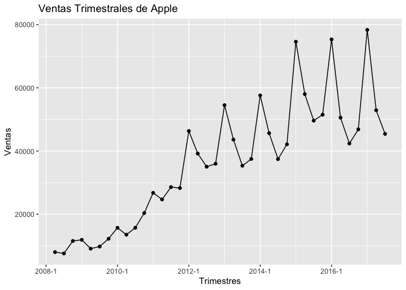

```r
df_new <- data.frame(value = as.vector(zVentas),
                     time = time(zVentas))
ggplot(df_new) +
  geom_point(aes(x = time,y = value)) +
  geom_line(aes(x = time,y = value)) +
  ylab("Ventas") +
  ggtitle("Ventas Trimestrales de Apple") +
  xlab("Trimestres")
```

Tendencia: tiene tendencia positiva, parece ser aditiva damped y no tiene ciclo. Estacionalidad: Claramente existe componente estacional multiplicativo, como puede observarse en el primer trimestre de cada año. La serie es no estacionaria en varianza y en media.

Seleccionamos el mejor modelo ETS de forma automatica

```r
#Select number of observation to compare forecast
cOmit = 3 #sacamos los 3 trimestres de 2017

#Data Size
nObs = length(zVentas)

#sub_sample
#oVentas=zVentas[1:(nObs-cOmit),]
oVentas <- window(zVentas,start = index(zVentas[1]),end = index(zVentas[nObs - cOmit]))

#test
pVentas <- window(zVentas,start = index(zVentas[nObs - cOmit+1]),end = index(zVentas[nObs]))

## Select automatic ETS
etsfit <- ets(oVentas)

#Results
summary(etsfit)
```

```
## ETS(M,A,M)
##
## Call:
##  ets(y = oVentas)
##
##   Smoothing parameters:
##     alpha = 0.493
##     beta  = 0.493
##     gamma = 0.507
##
##   Initial states:
##     l = 7125.3462
##     b = 1485.7975
##     s = 1.1511 1.1163 0.8322 0.9004
##
##   sigma:  0.1222
##
##      AIC     AICc      BIC
## 703.9538 711.1538 717.9519
##
## Training set error measures:
##                   ME     RMSE      MAE       MPE     MAPE      MASE      ACF1
## Training set -41.934 4120.155 2883.262 -0.297759 8.677434 0.4160202 0.1438481
```

El modelo es de tipo M,A,M, es decir, de error multiplicativo, tendencia aditiva y componente estacional multiplicativo.

MODELOS ARIMA

Estimamos el modelo ARIMA con la funcion autoarima sin marcar especificamente ningun valor de lambda para que el algoritmo encuentre el superparametro optimo para estimar el modelo.

```r
#ARIMA MODEL
fit1=auto.arima(oVentas)
summary(fit1)
```

```
## Series: oVentas
## ARIMA(1,0,0)(0,1,0)[4]
##
## Coefficients:
##          ar1
##       0.8331
## s.e.  0.0876
##
## sigma^2 estimated as 20474541:  log likelihood=-305.01
## AIC=614.02   AICc=614.45   BIC=616.89
##
## Training set error measures:
##                    ME     RMSE      MAE      MPE     MAPE      MASE       ACF1
## Training set 716.2193 4189.225 2797.277 2.986021 8.038297 0.4036137 0.05639445
```

Aqui observamos que obtenemos un modelo con menor MAPE (% de error medio cometido por la prediccion) que en el modelos ETS.

Obtenemos un modelo SARIMA, ARIMA con componente estacional ARIMA(1,0,0)(0,1,0)[4]. El componente principal tiene componente autorregresivo de 1 retardo. El componente estacional no tiene componente autoregresivo, y ademas requiere de una diferencia para hacer la serie estacionaria en media. Ninguno de los componentes depende de los errores que tuvieron lugar anteriormente. El [4] nos indica la cantidad de periodos anteriores (4 trimestres).

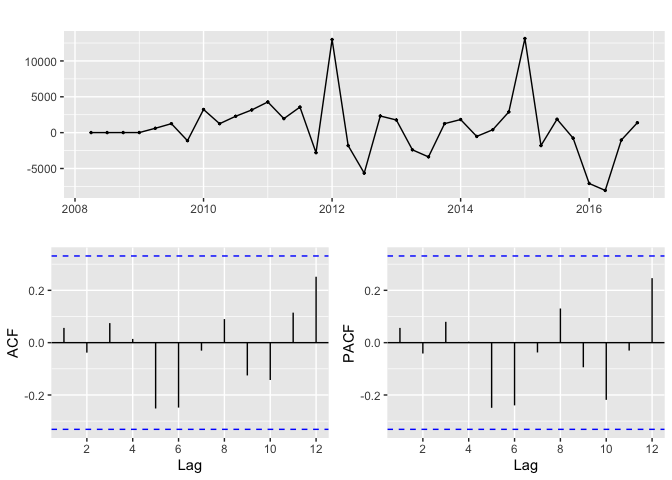

```r
#residual analysis
ggtsdisplay(fit1$residuals)
```

Como podemos observar prestando atencion a las bandas, los residuos se pueden calificar de ruido blanco.

Realizaremos el test de Box-Ljung, que consiste en contrastar si los retardos de la acf son cero a la vez:

```r
#box-Ljung Test
Box.test(fit1$residuals,lag=4, fitdf=3, type="Lj")
```

```
##
##  Box-Ljung test
##
## data:  fit1$residuals
## X-squared = 0.4126, df = 1, p-value = 0.5207
```

```r
Box.test(fit1$residuals,lag=8, fitdf=3, type="Lj")
```

```
##
##  Box-Ljung test
##
## data:  fit1$residuals
## X-squared = 6.3263, df = 5, p-value = 0.2757
```

```r
Box.test(fit1$residuals,lag=12, fitdf=3, type="Lj")
```

```
##
##  Box-Ljung test
##
## data:  fit1$residuals
## X-squared = 12.447, df = 9, p-value = 0.1893
```

Al ser los p-valor en todos los Box test mayores al nivel de significacion de 5% podemos considerar que todos los residuos son ruido blanco.

Ahora vamos a estimar y graficar esas predicciones con el modelo ARIMA ya que tiene menor error que el modelo ETS

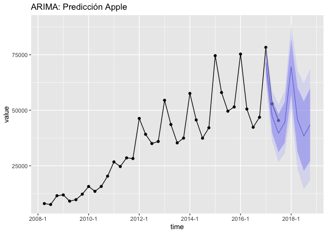

```r
fventas.arima=forecast(fit1)

ggplot(df_new)+geom_point(aes(x=time,y=value))+geom_line(aes(x=time,y=value))+ geom_forecast(fventas.arima,alpha=0.4)+ggtitle("ARIMA: Predicción Apple")
```

```r
fventas.arima
```

```
##         Point Forecast    Lo 80    Hi 80    Lo 95    Hi 95
## 2017 Q1       71450.81 65651.94 77249.68 62582.21 80319.41
## 2017 Q2       47330.16 39782.50 54877.81 35787.02 58873.30
## 2017 Q3       39669.64 31115.85 48223.43 26587.74 52751.54
## 2017 Q4       44612.27 35424.67 53799.86 30561.05 58663.48
## 2018 Q1       69584.84 57005.32 82164.35 50346.13 88823.54
## 2018 Q2       45775.57 31301.78 60249.36 23639.82 67911.33
## 2018 Q3       38374.48 22720.07 54028.89 14433.13 62315.83
## 2018 Q4       43533.24 27109.19 59957.29 18414.82 68651.65
```

# Conclusiones

Analizando los valores de la serie desde 2008 hasta el tercer trimestre del 2017 podemos observar que hay una tendencia creciente fuerte hasta el primer trimestre del 2015 donde se empieza a achatar o a perder fuerza. El gran crecimiento desde 2008 e incluso 2007 fue por la revolucion e innovacion que produjo la creacion del iphone, un smartphone capaz de hacer cosas que ningun otro participante del mercado de celulares habia logrado antes. Ya en 2015 esta tendencia se empieza a achatar un poco debido a la entrada de nuevos competidores en el mercado que equipararon en funcionalidades a los iphone y ademas, con precios rompedores lo que llevo a los usuarios a elegir otras alternativas. Al mismo tiempo, el tiempo medio de mantencion de un smartphone cambio. Hoy en dia, los usuarios suelen mantener los celulares por mas tiempo llegando a 3 años de media en posesion.

El gran desafio de Apple es dejar de depender tanto del iphone como fuente de ingresos ya que el 70% de sus ventas dependen de este producto lo que los hace muy sensibles a variaciones en las ventas del mismo. El desafio pasa por potenciar las ventas de otros productos como los servicios en la nube como Icloud, News, Homekits, Apple Arcade, Apple TV y lo que para mi es, hoy en dia, el producto estrella de la marca el apple Watch un reloj inteligente con muchas funcionalidades en lo que respecta a salud. Potenciar estos productos y servicios ayudara a continuar por el camino de la tendencia creciente que se veia mas pronunciado desde 2008 hasta el 2015.